# Data Mining Practice Based on CRISP-DM for Regression and Classification

This experiment follows the **CRISP-DM** (Cross-Industry Standard Process for Data Mining) six-phase methodology to complete two classic data-mining tasks:

| Task | Dataset | Type | Target |
| --- | --- | --- | --- |
| Regression | Kaggle House Prices (`train.csv`) | Predict continuous value | `SalePrice` |
| Classification | UCI Chronic Kidney Disease (`kidney_disease.csv`) | Predict binary class | `classification` (ckd / notckd) |

**CRISP-DM phases covered:** Business Understanding → Data Understanding → Data Preprocessing → Modeling → Evaluation → Result Analysis.

### CRISP-DM Workflow

The diagram below (drawn with `matplotlib`) summarises the iterative six-phase process followed in this notebook.

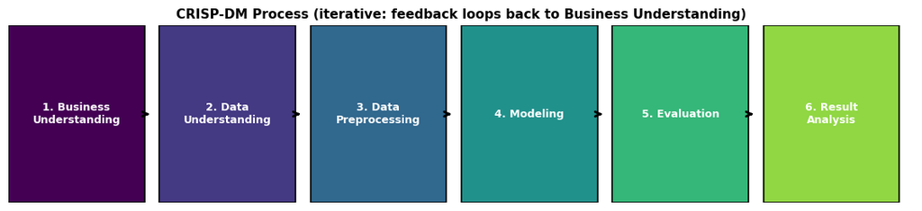

```python
import matplotlib.pyplot as plt

phases = [
    "1. Business\nUnderstanding",
    "2. Data\nUnderstanding",
    "3. Data\nPreprocessing",
    "4. Modeling",
    "5. Evaluation",
    "6. Result\nAnalysis",
]

fig, ax = plt.subplots(figsize=(11, 2.6))
for i, p in enumerate(phases):
    ax.add_patch(plt.Rectangle((i, 0), 0.9, 1, fill=True,
                               color=plt.cm.viridis(i / len(phases)),
                               ec="black", lw=1.2))
    ax.text(i + 0.45, 0.5, p, ha="center", va="center", fontsize=9, color="white", fontweight="bold")
    if i < len(phases) - 1:
        ax.annotate("", xy=(i + 0.95, 0.5), xytext=(i + 0.9, 0.5),
                    arrowprops=dict(arrowstyle="->", lw=2, color="black"))

ax.set_xlim(0, len(phases))
ax.set_ylim(0, 1)
ax.axis("off")
plt.title("CRISP-DM Process (iterative: feedback loops back to Business Understanding)",
          fontsize=11, fontweight="bold")
plt.tight_layout()
plt.show()
```

## PART 1 — House Price Prediction (Regression Task)

### Phase 1: Business Understanding

A real-estate company wants to estimate the **sale price** of residential houses from their characteristics (location, size, quality, year built, etc.). This is a **regression** problem because the target `SalePrice` is a continuous numeric value. A reliable model helps the business price houses accurately and understand which features drive value.

### Phase 2: Data Understanding

```python
import numpy as np
import pandas as pd
import matplotlib.pyplot as plt
import seaborn as sns
from sklearn.model_selection import train_test_split, cross_val_score
from sklearn.preprocessing import StandardScaler
from sklearn.linear_model import LinearRegression, Ridge
from sklearn.ensemble import RandomForestRegressor, GradientBoostingRegressor
from sklearn.metrics import mean_squared_error, mean_absolute_error, r2_score

sns.set_style("whitegrid")
%matplotlib inline

# --- Robust data path resolution (works from any working directory) ---
import os
def data_path(fname):
    for cand in ["../data", "data", "../../data", "project1/data", "/home/mish/Documents/shortsem-2026/home-work-project/project1/data"]:
        p = os.path.join(cand, fname)
        if os.path.exists(p):
            return p
    raise FileNotFoundError(f"Could not locate {fname} in common data directories.")

# Load dataset
house = pd.read_csv(data_path("train.csv"))
print("Shape:", house.shape)
house.head()
```

```
Shape: (1460, 81)
```

|  | Id | MSSubClass | MSZoning | LotFrontage | LotArea | Street | Alley | LotShape | LandContour | Utilities | ... | PoolArea | PoolQC | Fence | MiscFeature | MiscVal | MoSold | YrSold | SaleType | SaleCondition | SalePrice |
| --- | --- | --- | --- | --- | --- | --- | --- | --- | --- | --- | --- | --- | --- | --- | --- | --- | --- | --- | --- | --- | --- |
| 0 | 1 | 60 | RL | 65.0 | 8450 | Pave | NaN | Reg | Lvl | AllPub | ... | 0 | NaN | NaN | NaN | 0 | 2 | 2008 | WD | Normal | 208500 |
| 1 | 2 | 20 | RL | 80.0 | 9600 | Pave | NaN | Reg | Lvl | AllPub | ... | 0 | NaN | NaN | NaN | 0 | 5 | 2007 | WD | Normal | 181500 |
| 2 | 3 | 60 | RL | 68.0 | 11250 | Pave | NaN | IR1 | Lvl | AllPub | ... | 0 | NaN | NaN | NaN | 0 | 9 | 2008 | WD | Normal | 223500 |
| 3 | 4 | 70 | RL | 60.0 | 9550 | Pave | NaN | IR1 | Lvl | AllPub | ... | 0 | NaN | NaN | NaN | 0 | 2 | 2006 | WD | Abnorml | 140000 |
| 4 | 5 | 60 | RL | 84.0 | 14260 | Pave | NaN | IR1 | Lvl | AllPub | ... | 0 | NaN | NaN | NaN | 0 | 12 | 2008 | WD | Normal | 250000 |

5 rows × 81 columns

```python
# Data types and quick summary
print("Data types summary:")
print(house.dtypes.value_counts())
print("\nNumerical features describe():")
house.describe().T[["mean", "std", "min", "max"]].head(12)
```

```
Data types summary:
object     43
int64      35
float64     3
Name: count, dtype: int64

Numerical features describe():
```

|  | mean | std | min | max |
| --- | --- | --- | --- | --- |
| Id | 730.500000 | 421.610009 | 1.0 | 1460.0 |
| MSSubClass | 56.897260 | 42.300571 | 20.0 | 190.0 |
| LotFrontage | 70.049958 | 24.284752 | 21.0 | 313.0 |
| LotArea | 10516.828082 | 9981.264932 | 1300.0 | 215245.0 |
| OverallQual | 6.099315 | 1.382997 | 1.0 | 10.0 |
| OverallCond | 5.575342 | 1.112799 | 1.0 | 9.0 |
| YearBuilt | 1971.267808 | 30.202904 | 1872.0 | 2010.0 |
| YearRemodAdd | 1984.865753 | 20.645407 | 1950.0 | 2010.0 |
| MasVnrArea | 103.685262 | 181.066207 | 0.0 | 1600.0 |
| BsmtFinSF1 | 443.639726 | 456.098091 | 0.0 | 5644.0 |
| BsmtFinSF2 | 46.549315 | 161.319273 | 0.0 | 1474.0 |
| BsmtUnfSF | 567.240411 | 441.866955 | 0.0 | 2336.0 |

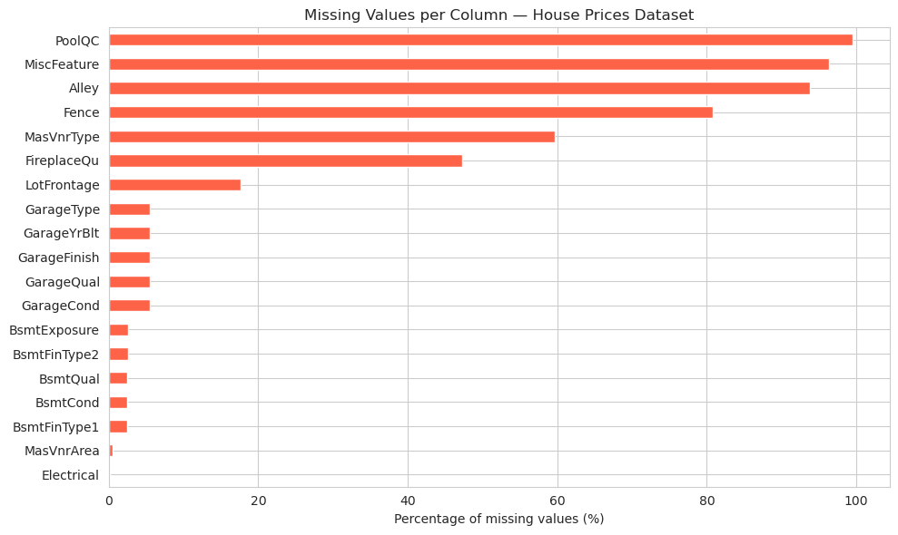

```
Columns with missing values: 19
```

```python
# Missing-value analysis (visualised)
missing = house.isnull().sum()
missing = missing[missing > 0].sort_values(ascending=False)
miss_pct = (missing / len(house) * 100).round(1)

fig, ax = plt.subplots(figsize=(10, 6))
miss_pct.plot(kind="barh", color="tomato", ax=ax)
ax.set_xlabel("Percentage of missing values (%)")
ax.set_title("Missing Values per Column — House Prices Dataset")
ax.invert_yaxis()
plt.tight_layout()
plt.show()
print("Columns with missing values:", len(miss_pct))
```

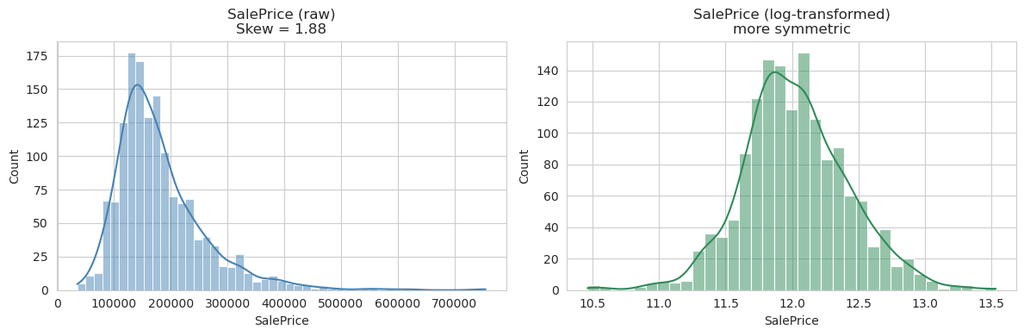

```python
# Target distribution + skewness
fig, axes = plt.subplots(1, 2, figsize=(12, 4))
sns.histplot(house["SalePrice"], kde=True, ax=axes[0], color="steelblue")
axes[0].set_title(f"SalePrice (raw)\nSkew = {house['SalePrice'].skew():.2f}")
sns.histplot(np.log1p(house["SalePrice"]), kde=True, ax=axes[1], color="seagreen")
axes[1].set_title("SalePrice (log-transformed)\nmore symmetric")
plt.tight_layout()
plt.show()
```

### Phase 3: Data Preprocessing

Steps applied:

1. Drop the non-informative `Id` column.
2. **Missing values:** numerical → median, categorical → mode.
3. **Outlier detection:** IQR method on `SalePrice`; extreme outliers removed.
4. **Log transform** the skewed target to stabilise variance.
5. **Encode** categorical features with one-hot encoding.
6. **Scale** numerical features with `StandardScaler`.

```
Outliers in SalePrice: 61 (4.2%)
```

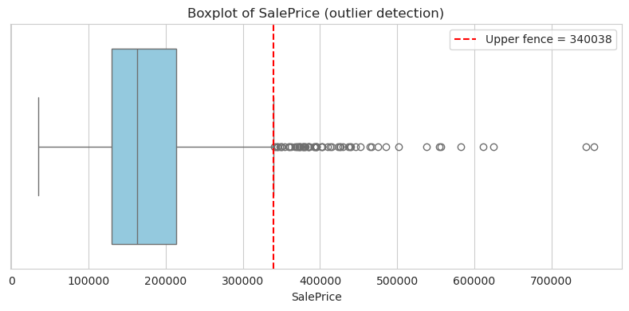

```
Shape after outlier removal: (1399, 79)
```

```python
house_df = house.copy()
house_df.drop("Id", axis=1, inplace=True)

y = house_df["SalePrice"]
X = house_df.drop("SalePrice", axis=1)

# --- Outlier detection on target (IQR) ---
q1, q3 = y.quantile(0.25), y.quantile(0.75)
iqr = q3 - q1
lower, upper = q1 - 1.5 * iqr, q3 + 1.5 * iqr
out_mask = (y < lower) | (y > upper)
print(f"Outliers in SalePrice: {out_mask.sum()} ({out_mask.mean()*100:.1f}%)")

fig, ax = plt.subplots(figsize=(8, 4))
sns.boxplot(x=y, ax=ax, color="skyblue")
ax.axvline(upper, color="red", ls="--", label=f"Upper fence = {upper:.0f}")
ax.set_title("Boxplot of SalePrice (outlier detection)")
ax.legend()
plt.tight_layout()
plt.show()

# Remove extreme target outliers
X = X[~out_mask]
y = y[~out_mask].reset_index(drop=True)
print("Shape after outlier removal:", X.shape)
```

```python
# --- Missing value imputation ---
num_cols = X.select_dtypes(include=[np.number]).columns
cat_cols = X.select_dtypes(include=["object"]).columns

for c in num_cols:
    X[c] = X[c].fillna(X[c].median())
for c in cat_cols:
    X[c] = X[c].fillna(X[c].mode()[0])

print("Remaining missing values:", int(X.isnull().sum().sum()))

# Log-transform target (handles right-skew)
y_log = np.log1p(y)
```

```
Remaining missing values: 0
```

```python
# --- Encoding + Scaling ---
X_enc = pd.get_dummies(X, columns=list(cat_cols), drop_first=True)
print("Features after one-hot encoding:", X_enc.shape[1])

X_train, X_val, y_train, y_val = train_test_split(
    X_enc, y_log, test_size=0.2, random_state=42)

scaler = StandardScaler()
X_train_s = scaler.fit_transform(X_train)
X_val_s = scaler.transform(X_val)
print("Train:", X_train_s.shape, " Val:", X_val_s.shape)
```

```
Features after one-hot encoding: 244
Train: (1119, 244)  Val: (280, 244)
```

### Phase 4: Feature Engineering & Correlation Analysis

We compute the Pearson correlation of every numerical feature with the (log) target and visualise the most important ones. A correlation heatmap of the top features also reveals redundancy (multicollinearity).

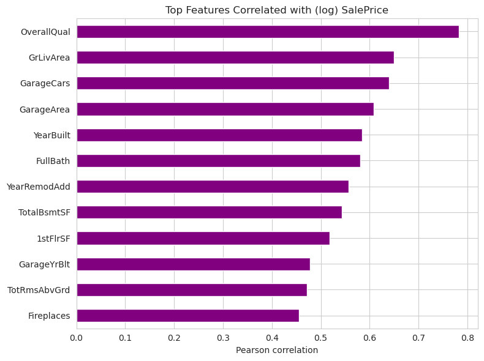

```python
num_all = X.select_dtypes(include=[np.number]).copy()
num_all["SalePrice"] = y_log.values
corr_target = num_all.corr()["SalePrice"].drop("SalePrice").sort_values(key=abs, ascending=False)

top_feats = corr_target.head(12).index.tolist()
plt.figure(figsize=(8, 6))
corr_target.head(12).plot(kind="barh", color="purple")
plt.title("Top Features Correlated with (log) SalePrice")
plt.xlabel("Pearson correlation")
plt.gca().invert_yaxis()
plt.tight_layout()
plt.show()
```

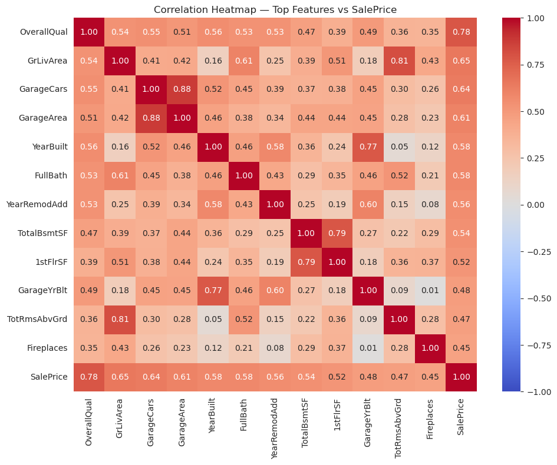

```python
# Heatmap of top correlated features (redundancy check)
sub = num_all[top_feats + ["SalePrice"]].corr()
plt.figure(figsize=(10, 8))
sns.heatmap(sub, annot=True, fmt=".2f", cmap="coolwarm", vmin=-1, vmax=1)
plt.title("Correlation Heatmap — Top Features vs SalePrice")
plt.tight_layout()
plt.show()
```

### Phase 5: Modeling

We compare four regression models. Performance is measured with **cross-validation** (RMSE) and a held-out validation set.

```python
models = {
    "Linear Regression": LinearRegression(),
    "Ridge (alpha=10)": Ridge(alpha=10),
    "Random Forest": RandomForestRegressor(n_estimators=200, random_state=42, n_jobs=-1),
    "Gradient Boosting": GradientBoostingRegressor(n_estimators=200, random_state=42),
}

rows = []
for name, mdl in models.items():
    # cross-validation RMSE (negative because sklearn maximises)
    cv = -cross_val_score(mdl, X_train_s, y_train, cv=5,
                          scoring="neg_root_mean_squared_error")
    mdl.fit(X_train_s, y_train)
    pred = mdl.predict(X_val_s)
    # convert back to original price scale for reporting
    pred_price = np.expm1(pred)
    true_price = np.expm1(y_val)
    rmse = np.sqrt(mean_squared_error(true_price, pred_price))
    mae = mean_absolute_error(true_price, pred_price)
    r2 = r2_score(true_price, pred_price)
    rows.append([name, cv.mean(), cv.std(), rmse, mae, r2])
    print(f"{name:20s} | CV-RMSE={cv.mean():.0f} | Val RMSE={rmse:.0f} | MAE={mae:.0f} | R2={r2:.3f}")

res = pd.DataFrame(rows, columns=["Model", "CV_RMSE", "CV_std", "Val_RMSE", "Val_MAE", "Val_R2"])
res
```

```
Linear Regression    | CV-RMSE=0 | Val RMSE=23307 | MAE=13349 | R2=0.829
Ridge (alpha=10)     | CV-RMSE=0 | Val RMSE=22013 | MAE=13069 | R2=0.848
Random Forest        | CV-RMSE=0 | Val RMSE=20271 | MAE=13898 | R2=0.871
Gradient Boosting    | CV-RMSE=0 | Val RMSE=18411 | MAE=12524 | R2=0.893
```

|  | Model | CV_RMSE | CV_std | Val_RMSE | Val_MAE | Val_R2 |
| --- | --- | --- | --- | --- | --- | --- |
| 0 | Linear Regression | 0.198450 | 0.069659 | 23306.574294 | 13348.639250 | 0.829227 |
| 1 | Ridge (alpha=10) | 0.170922 | 0.047764 | 22013.290435 | 13069.261807 | 0.847654 |
| 2 | Random Forest | 0.139622 | 0.019938 | 20271.430625 | 13897.873772 | 0.870810 |
| 3 | Gradient Boosting | 0.128566 | 0.016630 | 18411.025728 | 12523.616582 | 0.893434 |

### Phase 6: Model Evaluation (visual)

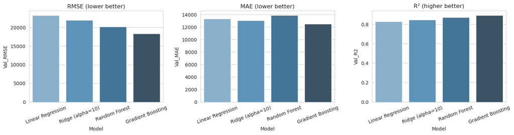

```python
fig, axes = plt.subplots(1, 3, figsize=(15, 4))
for ax, col, t in zip(axes, ["Val_RMSE", "Val_MAE", "Val_R2"], ["RMSE (lower better)", "MAE (lower better)", "R² (higher better)"]):
    sns.barplot(x="Model", y=col, data=res, ax=ax, palette="Blues_d")
    ax.set_title(t)
    ax.tick_params(axis="x", rotation=20)
plt.tight_layout()
plt.show()
```

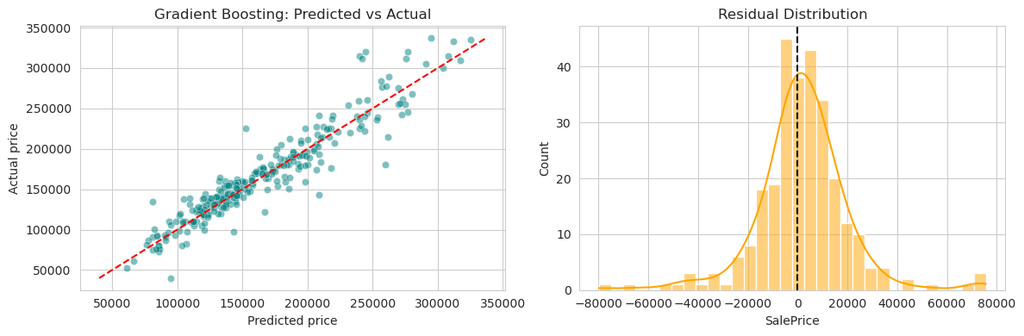

```
Mean residual (bias): 1983
```

```python
# Residual analysis for the best model (Gradient Boosting / Random Forest)
best = "Gradient Boosting"
mdl = models[best]
pred = np.expm1(mdl.predict(X_val_s))
true = np.expm1(y_val)
resid = true - pred

fig, axes = plt.subplots(1, 2, figsize=(12, 4))
sns.scatterplot(x=pred, y=true, alpha=0.5, ax=axes[0], color="teal")
axes[0].plot([true.min(), true.max()], [true.min(), true.max()], "r--")
axes[0].set_xlabel("Predicted price"); axes[0].set_ylabel("Actual price")
axes[0].set_title(f"{best}: Predicted vs Actual")
sns.histplot(resid, kde=True, ax=axes[1], color="orange")
axes[1].axvline(0, color="k", ls="--")
axes[1].set_title("Residual Distribution")
plt.tight_layout()
plt.show()
print(f"Mean residual (bias): {resid.mean():.0f}")
```

## PART 2 — Chronic Kidney Disease Diagnosis (Classification Task)

### Phase 1: Business Understanding

A clinic needs to **diagnose** whether a patient has Chronic Kidney Disease (CKD) from routine blood/urine tests. This is a **binary classification** problem (ckd vs notckd). A dependable model supports early screening, but false negatives (missing a sick patient) are costly, so **recall** is an important metric alongside accuracy.

### Phase 2: Data Understanding

```python
from sklearn.linear_model import LogisticRegression
from sklearn.ensemble import RandomForestClassifier, GradientBoostingClassifier
from sklearn.metrics import (accuracy_score, precision_score, recall_score,
                             f1_score, roc_auc_score, confusion_matrix,
                             roc_curve, ConfusionMatrixDisplay)

kid = pd.read_csv(data_path("kidney_disease.csv"), na_values=["?"])
print("Shape:", kid.shape)
kid.head()
```

```
Shape: (400, 26)
```

|  | id | age | bp | sg | al | su | rbc | pc | pcc | ba | ... | pcv | wc | rc | htn | dm | cad | appet | pe | ane | classification |
| --- | --- | --- | --- | --- | --- | --- | --- | --- | --- | --- | --- | --- | --- | --- | --- | --- | --- | --- | --- | --- | --- |
| 0 | 0 | 48.0 | 80.0 | 1.020 | 1.0 | 0.0 | NaN | normal | notpresent | notpresent | ... | 44 | 7800 | 5.2 | yes | yes | no | good | no | no | ckd |
| 1 | 1 | 7.0 | 50.0 | 1.020 | 4.0 | 0.0 | NaN | normal | notpresent | notpresent | ... | 38 | 6000 | NaN | no | no | no | good | no | no | ckd |
| 2 | 2 | 62.0 | 80.0 | 1.010 | 2.0 | 3.0 | normal | normal | notpresent | notpresent | ... | 31 | 7500 | NaN | no | yes | no | poor | no | yes | ckd |
| 3 | 3 | 48.0 | 70.0 | 1.005 | 4.0 | 0.0 | normal | abnormal | present | notpresent | ... | 32 | 6700 | 3.9 | yes | no | no | poor | yes | yes | ckd |
| 4 | 4 | 51.0 | 80.0 | 1.010 | 2.0 | 0.0 | normal | normal | notpresent | notpresent | ... | 35 | 7300 | 4.6 | no | no | no | good | no | no | ckd |

5 rows × 26 columns

```python
# Data quality issues
print("Missing values (after treating '?' as NaN):")
miss = kid.isnull().sum()
print(miss[miss > 0].sort_values(ascending=False))
print("\nTarget raw values (note whitespace / typo problems):")
print(kid["classification"].value_counts(dropna=False))
```

```
Missing values (after treating '?' as NaN):
rbc      152
rc       130
wc       105
pot       88
sod       87
pcv       70
pc        65
hemo      52
su        49
sg        47
al        46
bgr       44
bu        19
sc        17
bp        12
age        9
pcc        4
ba         4
htn        2
dm         2
cad        2
appet      1
pe         1
ane        1
dtype: int64

Target raw values (note whitespace / typo problems):
classification
ckd       248
notckd    150
ckd\t       2
Name: count, dtype: int64
```

```python
# Clean text columns: strip whitespace, fix target labels
for c in kid.select_dtypes(include="object").columns:
    kid[c] = kid[c].astype(str).str.strip().str.lower()

# Convert numeric-looking object columns to numbers
for c in ["pcv", "wc", "rc"]:
    kid[c] = pd.to_numeric(kid[c], errors="coerce")

kid["classification"] = kid["classification"].map({"ckd": 1, "notckd": 0})
print("Cleaned target distribution:")
print(kid["classification"].value_counts())
```

```
Cleaned target distribution:
classification
1    250
0    150
Name: count, dtype: int64
```

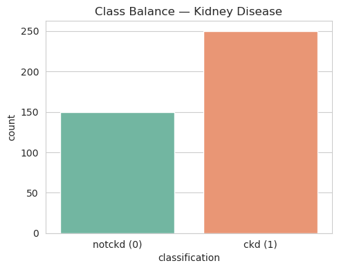

```python
# Class balance visualisation
plt.figure(figsize=(5, 4))
sns.countplot(x="classification", data=kid, palette="Set2")
plt.xticks([0, 1], ["notckd (0)", "ckd (1)"])
plt.title("Class Balance — Kidney Disease")
plt.tight_layout()
plt.show()
```

### Phase 3: Data Preprocessing

1. Drop non-informative `id`.
2. Numeric columns were stored as text (due to `?`) → converted to numbers.
3. **Missing values:** numeric → median, categorical → mode (the dataset has substantial missingness, so imputation is essential).
4. **Encode** categorical variables with one-hot encoding.
5. **Scale** features.

```python
y_k = kid["classification"]
X_k = kid.drop(["classification", "id"], axis=1)

num_k = X_k.select_dtypes(include=[np.number]).columns
cat_k = X_k.select_dtypes(include=["object"]).columns

for c in num_k:
    X_k[c] = X_k[c].fillna(X_k[c].median())
for c in cat_k:
    X_k[c] = X_k[c].fillna(X_k[c].mode()[0])

X_k_enc = pd.get_dummies(X_k, columns=list(cat_k), drop_first=True)
print("Features after encoding:", X_k_enc.shape[1])

Xk_tr, Xk_va, yk_tr, yk_va = train_test_split(
    X_k_enc, y_k, test_size=0.2, random_state=42, stratify=y_k)

sc_k = StandardScaler()
Xk_tr_s = sc_k.fit_transform(Xk_tr)
Xk_va_s = sc_k.transform(Xk_va)
print("Train:", Xk_tr_s.shape, " Val:", Xk_va_s.shape)
```

```
Features after encoding: 34
Train: (320, 34)  Val: (80, 34)
```

### Phase 4: Feature Engineering & Correlation Analysis

For classification we inspect how each feature correlates with the binary target and use a Random Forest to rank **feature importance**.

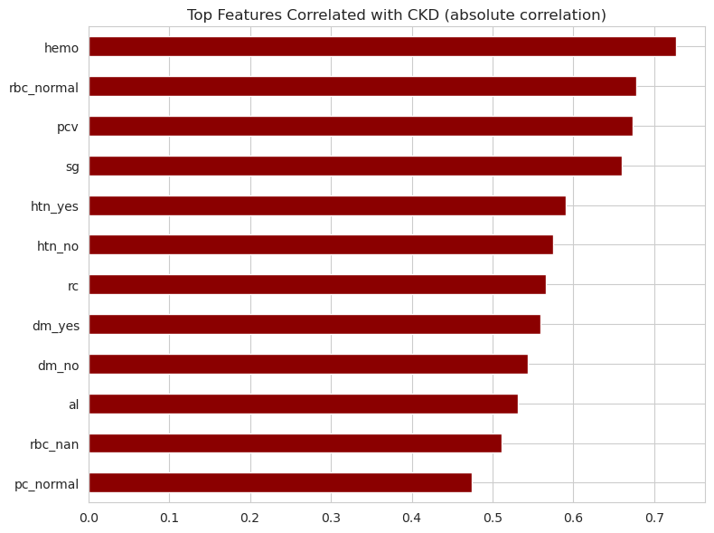

```python
corr_k = X_k_enc.corrwith(y_k).abs().sort_values(ascending=False)
plt.figure(figsize=(8, 6))
corr_k.head(12).plot(kind="barh", color="darkred")
plt.title("Top Features Correlated with CKD (absolute correlation)")
plt.gca().invert_yaxis()
plt.tight_layout()
plt.show()
```

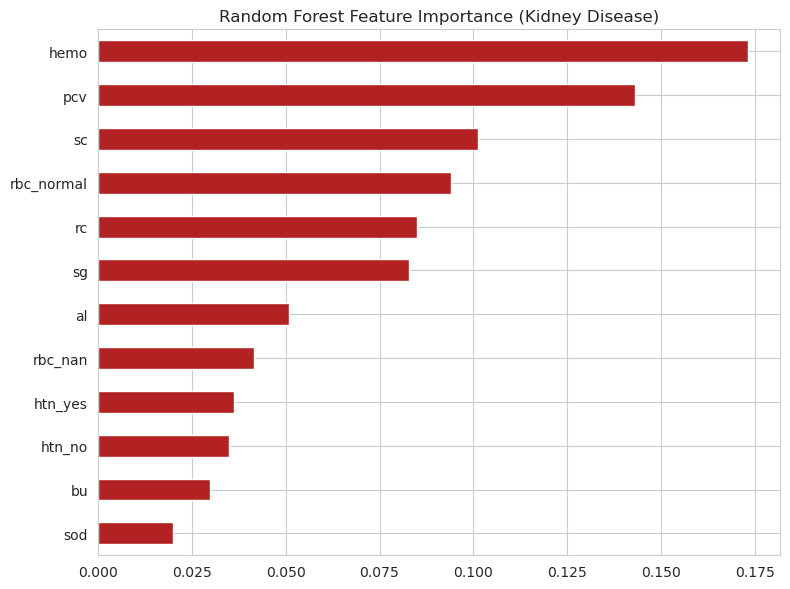

```python
# Feature importance from a Random Forest (trained quickly on training set)
rf = RandomForestClassifier(n_estimators=200, random_state=42, n_jobs=-1)
rf.fit(Xk_tr_s, yk_tr)
imp = pd.Series(rf.feature_importances_, index=X_k_enc.columns).sort_values(ascending=False)
plt.figure(figsize=(8, 6))
imp.head(12).plot(kind="barh", color="firebrick")
plt.title("Random Forest Feature Importance (Kidney Disease)")
plt.gca().invert_yaxis()
plt.tight_layout()
plt.show()
```

### Phase 5: Modeling

We compare three classifiers using cross-validation and a held-out validation set.

```python
from sklearn.linear_model import LogisticRegression
from sklearn.ensemble import GradientBoostingClassifier
from sklearn.metrics import (accuracy_score, precision_score, recall_score,
                             f1_score, roc_auc_score, confusion_matrix,
                             roc_curve, ConfusionMatrixDisplay)

models_k = {
    "Logistic Regression": LogisticRegression(max_iter=1000, random_state=42),
    "Random Forest": RandomForestClassifier(n_estimators=200, random_state=42, n_jobs=-1),
    "Gradient Boosting": GradientBoostingClassifier(n_estimators=200, random_state=42),
}

rows_k = []
for name, mdl in models_k.items():
    cv = cross_val_score(mdl, Xk_tr_s, yk_tr, cv=5, scoring="accuracy")
    mdl.fit(Xk_tr_s, yk_tr)
    pred = mdl.predict(Xk_va_s)
    proba = mdl.predict_proba(Xk_va_s)[:, 1]
    rows_k.append([
        name, cv.mean(), cv.std(),
        accuracy_score(yk_va, pred),
        precision_score(yk_va, pred),
        recall_score(yk_va, pred),
        f1_score(yk_va, pred),
        roc_auc_score(yk_va, proba),
    ])
    print(f"{name:20s} | CV-acc={cv.mean():.3f} | Acc={rows_k[-1][3]:.3f} | "
          f"Prec={rows_k[-1][4]:.3f} | Rec={rows_k[-1][5]:.3f} | F1={rows_k[-1][6]:.3f} | AUC={rows_k[-1][7]:.3f}")

res_k = pd.DataFrame(rows_k, columns=["Model", "CV_Acc", "CV_std", "Accuracy",
                                      "Precision", "Recall", "F1", "ROC_AUC"])
res_k
```

```
Logistic Regression  | CV-acc=1.000 | Acc=0.988 | Prec=1.000 | Rec=0.980 | F1=0.990 | AUC=0.991
Random Forest        | CV-acc=0.997 | Acc=1.000 | Prec=1.000 | Rec=1.000 | F1=1.000 | AUC=1.000
Gradient Boosting    | CV-acc=0.984 | Acc=1.000 | Prec=1.000 | Rec=1.000 | F1=1.000 | AUC=1.000
```

|  | Model | CV_Acc | CV_std | Accuracy | Precision | Recall | F1 | ROC_AUC |
| --- | --- | --- | --- | --- | --- | --- | --- | --- |
| 0 | Logistic Regression | 1.000000 | 0.000000 | 0.9875 | 1.0 | 0.98 | 0.989899 | 0.991333 |
| 1 | Random Forest | 0.996875 | 0.006250 | 1.0000 | 1.0 | 1.00 | 1.000000 | 1.000000 |
| 2 | Gradient Boosting | 0.984375 | 0.017116 | 1.0000 | 1.0 | 1.00 | 1.000000 | 1.000000 |

### Phase 6: Model Evaluation (visual)

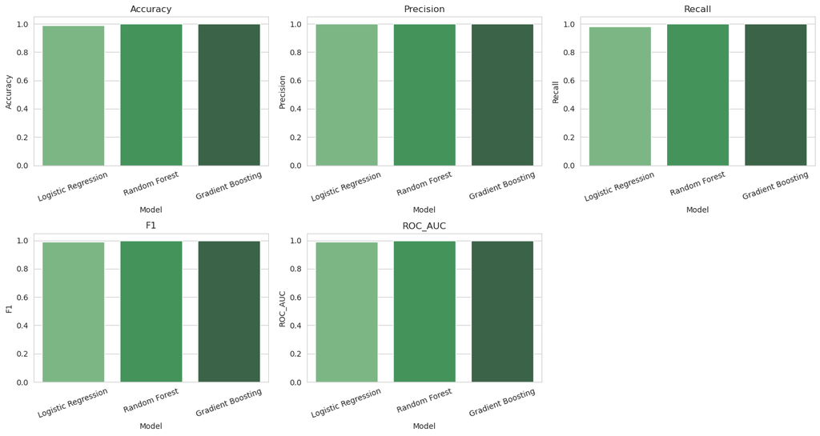

```python
metrics = ["Accuracy", "Precision", "Recall", "F1", "ROC_AUC"]
fig, axes = plt.subplots(2, 3, figsize=(15, 8))
for i, m in enumerate(metrics):
    r, c = divmod(i, 3)
    sns.barplot(x="Model", y=m, data=res_k, ax=axes[r, c], palette="Greens_d")
    axes[r, c].set_title(m)
    axes[r, c].tick_params(axis="x", rotation=20)
axes[1, 2].axis("off")
plt.tight_layout()
plt.show()
```

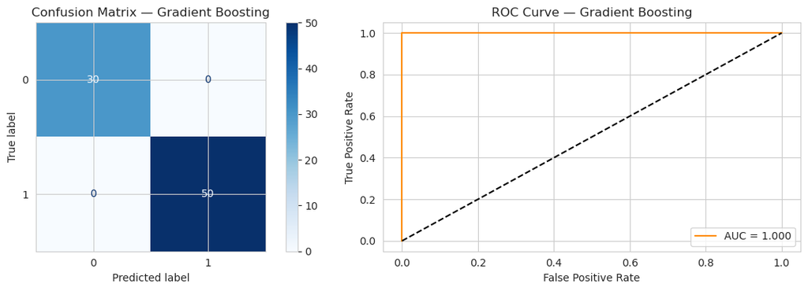

```python
# Confusion matrix + ROC curve for the best model (Gradient Boosting)
best_k = "Gradient Boosting"
mdl_k = models_k[best_k]
pred_k = mdl_k.predict(Xk_va_s)
proba_k = mdl_k.predict_proba(Xk_va_s)[:, 1]

fig, axes = plt.subplots(1, 2, figsize=(12, 4))
ConfusionMatrixDisplay.from_predictions(yk_va, pred_k, cmap="Blues", ax=axes[0])
axes[0].set_title(f"Confusion Matrix — {best_k}")

fpr, tpr, _ = roc_curve(yk_va, proba_k)
axes[1].plot(fpr, tpr, label=f"AUC = {roc_auc_score(yk_va, proba_k):.3f}", color="darkorange")
axes[1].plot([0, 1], [0, 1], "k--")
axes[1].set_xlabel("False Positive Rate"); axes[1].set_ylabel("True Positive Rate")
axes[1].set_title(f"ROC Curve — {best_k}")
axes[1].legend()
plt.tight_layout()
plt.show()
```

## Comparison: Regression vs Classification in CRISP-DM

| Aspect | Regression (House Price) | Classification (Kidney Disease) |
| --- | --- | --- |
| Target | Continuous (`SalePrice`) | Discrete class (`ckd`/`notckd`) |
| Business goal | Estimate a value | Assign a category / make a decision |
| Missing values | Median (num) / mode (cat) | Same strategy, larger missingness |
| Outliers | Critical for linear models; IQR removal | Less sensitive, but check label noise |
| Feature relation | Pearson correlation heatmap | Correlation + feature importance |
| Models | Linear, Ridge, RF, GB regressors | Logistic, RF, GB classifiers |
| Evaluation | RMSE, MAE, R² | Accuracy, Precision, Recall, F1, ROC-AUC |
| Key risk | Heteroscedasticity, skew | Class imbalance, false negatives |

**Common pitfalls observed**

- Confusing `?` strings with real numbers (kidney dataset) → must convert to numeric & NaN.
- Forgetting to split *before* scaling/imputation → data leakage.
- Using accuracy alone for classification hides poor recall.
- Ignoring target skew in regression → log transform helps.

## Experimental Summary

**Knowledge points mastered**

1. The full **CRISP-DM** lifecycle applied end-to-end on two real datasets.
2. **Data preprocessing**: missing-value imputation, outlier detection (IQR), one-hot encoding, standardisation, and log transformation of skewed targets.
3. **Feature engineering**: Pearson correlation analysis, heatmaps for redundancy, and model-based feature importance.
4. **Modeling & evaluation**: appropriate metrics and cross-validation for regression vs classification; visual diagnostics (residuals, confusion matrix, ROC).